# R Sharing session - diversity

Chong Kwek Yan

2023-10-22

## Data

You’re welcome to use your own data. Otherwise, you can use the data from the `novelforestSG` R package.

```r
library(novelforestSG)
```

After loading this library, the data we will be using can simply be accessed by typing `novelforest_data`. It looks something like this:

```r
head(novelforest_data)
```

```
##   patch plot    UID            species stem dbh_2011
## 1    AD  AD1 AD1T02 Hevea brasiliensis    1      6.5
## 2    AD  AD1 AD1T04 Hevea brasiliensis    1      5.2
## 3    AD  AD1 AD1T05 Hevea brasiliensis    1      5.5
## 4    AD  AD1 AD1T06   Cinnamomum iners    1      6.8
## 5    AD  AD1 AD1T07 Hevea brasiliensis    1      5.3
## 6    AD  AD1 AD1T08 Hevea brasiliensis    1      8.2
```

You can read more about the this dataset [here](https://hrlai.github.io/novelforestSG/).

```r
comm_stem <- xtabs(~ plot + species, data = novelforest_data)

comm_stem[1:10, 1:4]
```

```
##      species
## plot  Acacia auriculiformis Adenanthera pavonina Adinandra dumosa
##   AD1                     0                    0                0
##   AD2                     0                    0                0
##   AD3                     0                    0                0
##   AD4                     0                    0                0
##   AD5                     0                    0                0
##   AW1                     0                    0                6
##   AW2                     9                    0                0
##   AW3                     0                    0                9
##   AW4                     4                    0                0
##   AW5                    44                    0                0
##      species
## plot  Aidia densiflora
##   AD1                0
##   AD2                0
##   AD3                0
##   AD4                0
##   AD5                0
##   AW1                0
##   AW2                0
##   AW3                0
##   AW4                0
##   AW5                0
```

This table is what is usually meant by the ‘community composition’ of samples, sites, assemblages, etc. Each species is a property of the site, measured by abundance. Each row in this table has as many properties, or ‘variables’ as there are species. This is why composition of communities is described as ‘multivariate’–or multidimensional–data. However, multivariate data in its raw form is complex, so we often wish to simplify it, e.g., by reducing it to a single number for each sample that describes one particular property of that sample, drawing from information on other properties. ‘Diversity’ is one of these properties.

If there was nothing on the left-hand side of the `~`, each row is taken as an instance to be summed. Since each row was one tree/stem, this community composition matrix is using stem counts as the measure of abundance. If you have counts of each species at each instance of observation in your data, e.g., a `counts` column where 6 indicates six counts of, say, Javan myna, then you can put `counts` on the left-hand side of the `~`. Any type of measure can be used; e.g., if we want to use basal area at breast height of trees as an abundance measure:

```r
novelforest_data$ba_2011 <- pi*(novelforest_data$dbh_2011/2)^2

comm_ba <- xtabs(ba_2011 ~ plot + species, data = novelforest_data)

comm_ba[1:10, 1:4]
```

```
##      species
## plot  Acacia auriculiformis Adenanthera pavonina Adinandra dumosa
##   AD1                0.0000               0.0000           0.0000
##   AD2                0.0000               0.0000           0.0000
##   AD3                0.0000               0.0000           0.0000
##   AD4                0.0000               0.0000           0.0000
##   AD5                0.0000               0.0000           0.0000
##   AW1                0.0000               0.0000         731.1429
##   AW2             1439.9568               0.0000           0.0000
##   AW3                0.0000               0.0000         963.1102
##   AW4              971.0584               0.0000           0.0000
##   AW5             5706.9308               0.0000           0.0000
##      species
## plot  Aidia densiflora
##   AD1           0.0000
##   AD2           0.0000
##   AD3           0.0000
##   AD4           0.0000
##   AD5           0.0000
##   AW1           0.0000
##   AW2           0.0000
##   AW3           0.0000
##   AW4           0.0000
##   AW5           0.0000
```

## Part I: Calculating diversity

The first part of this session is on calculating various measures of ‘diversity’ for each sample, assemblage, etc. This is called $\alpha$ (‘alpha’) diversity, or ‘local’ diversity.

The `vegan` R package is a well-established package for dealing with community ecology data.

```r
library(vegan)
```

In a nutshell, diversity consists of two components. One is the ‘richness’ component, which is simply the number of different things (in this case, number of species).

```r
(alpha_d0 <- specnumber(comm_stem))
```

```
##  AD1  AD2  AD3  AD4  AD5  AW1  AW2  AW3  AW4  AW5 BBE1 BBE2 BBE3 BBE4 BBE5 BBH1
##    5   11    5    4    3   12    9   12    7    8   10    9   12   10    6   10
## BBH2 BBH3 BBH4 BBH5 BBN1 BBN2 BBN3 BBN4 BBN5 BBT1 BBT2 BBT3 BBT4 BBT5  BR1  BR2
##    5    8    9    5   13    6   12    9    6    6    8    8    6    4    5    7
##  BR3  CL1  CL2  CL3  CL4  CL5  DO1  DO2  DO3  DO4  DO5  GA1  GA2  GA3  GA4  GA5
##    1    7    4    7    7   10    9   11    6    8    8   11    8   16   12   13
##  IK1  IK2  IK3  IK4  IK5  JR1  JR2  JR3  JR4  JR5  KJ1  KJ2  KJ3  KJ4  KJ5  LD1
##    3    4    3    3    3    3    9    7    5    7    9    8    6    7    3   11
##  LD2  LD3  LD4  LD5  PO1  PO2  PO3  PO4  PO5  PT1  PT2  PT3  PT4  PT5  SA1  SA2
##   10   12    7    8    8    7    5    2    4    5   11    3    7    5    8   10
##  SA3  SA4  SA5  SJ1  SJ2  SJ3  SJ4  SJ5  TP1  TP2  TP3  TP4  UT1  UT2  UT3  UT4
##    8   10    6    8   11    5    2    6    6    5    7    4    7   10   12    9
##  UT5
##   11
```

The other component is ‘evenness’, i.e., how equally distributed the quantities are of individual things–in this case, the relative abundances of species. Note that for this to be meaningful, the relative quantities must be on the same units. E.g., it is meaningless if some species are in counts while others are in cover, biomass, etc. For the same richness, composition that is more even is considered more diverse.

The problem is: how much ‘weight’ to place on the evenness of communities to derive diversity? If no weight at all, i.e., relative abundances are not taken into account, then diversity is simply richness.

### Shannon’s diversity? Simpson’s diversity?

One diversity measure commonly taught in introductory ecology classes is the Shannon index, also known as the Shannon-Weiner index, or Shannon entropy.

```r
(alpha_sh <- diversity(comm_stem, index = "shannon"))
```

```
##       AD1       AD2       AD3       AD4       AD5       AW1       AW2       AW3
## 1.1055299 1.8522889 0.5752281 0.3127369 0.9743148 2.2312805 1.7556069 2.1755020
##       AW4       AW5      BBE1      BBE2      BBE3      BBE4      BBE5      BBH1
## 1.5752666 1.0480110 1.1414332 1.9131576 1.6089893 1.4254079 1.1174629 1.8669819
##      BBH2      BBH3      BBH4      BBH5      BBN1      BBN2      BBN3      BBN4
## 0.7513771 1.7569160 1.4339026 1.4113036 2.3769923 0.9300373 2.1659765 1.1855726
##      BBN5      BBT1      BBT2      BBT3      BBT4      BBT5       BR1       BR2
## 0.6694323 1.5403058 1.5179217 1.1146256 0.9495937 0.4845306 1.4938857 1.4178821
##       BR3       CL1       CL2       CL3       CL4       CL5       DO1       DO2
## 0.0000000 1.5097691 0.8002352 1.4877448 1.5126699 2.1030693 1.8537950 2.1139157
##       DO3       DO4       DO5       GA1       GA2       GA3       GA4       GA5
## 1.3701266 1.4276904 1.9433779 1.7573805 1.4699537 2.0115303 1.9265534 1.6648078
##       IK1       IK2       IK3       IK4       IK5       JR1       JR2       JR3
## 0.2771134 1.3060092 0.5353832 0.9743148 0.6001661 0.2164084 1.8711873 1.4884915
##       JR4       JR5       KJ1       KJ2       KJ3       KJ4       KJ5       LD1
## 1.2367900 1.5716826 1.7731059 2.0431919 0.8327213 1.7917595 0.9002561 1.9922628
##       LD2       LD3       LD4       LD5       PO1       PO2       PO3       PO4
## 1.5391653 1.5334720 1.4847764 1.4787515 1.4347410 1.2650218 1.3479101 0.3767702
##       PO5       PT1       PT2       PT3       PT4       PT5       SA1       SA2
## 0.7321908 1.4088131 1.8324462 0.8599673 1.7941812 1.4196326 1.8544395 2.0361789
##       SA3       SA4       SA5       SJ1       SJ2       SJ3       SJ4       SJ5
## 1.2587971 1.6555798 1.0333062 1.7112904 2.1724796 1.2412047 0.6931472 1.3913667
##       TP1       TP2       TP3       TP4       UT1       UT2       UT3       UT4
## 1.4251581 1.2440167 1.3064251 1.0971664 0.7646642 2.1403895 2.1035252 1.8908261
##       UT5
## 2.1189551
```

Another commonly taught diversity measure is the Simpson index, or more accurately the *complement* of the Simpson index, also known as the Gini-Simpson index.

```r
(alpha_si <- diversity(comm_stem, index = "simpson"))
```

```
##        AD1        AD2        AD3        AD4        AD5        AW1        AW2
## 0.54064272 0.76731302 0.24990388 0.12476371 0.59375000 0.87197232 0.78407908
##        AW3        AW4        AW5       BBE1       BBE2       BBE3       BBE4
## 0.86011080 0.75056587 0.48925781 0.45746528 0.82000000 0.62819576 0.62962963
##       BBE5       BBH1       BBH2       BBH3       BBH4       BBH5       BBN1
## 0.51530612 0.78698225 0.38297872 0.77440000 0.66642012 0.70833333 0.88960000
##       BBN2       BBN3       BBN4       BBN5       BBT1       BBT2       BBT3
## 0.42125000 0.85813149 0.50823045 0.27876397 0.72727273 0.67333333 0.48880000
##       BBT4       BBT5        BR1        BR2        BR3        CL1        CL2
## 0.44000000 0.21626298 0.75925926 0.65632653 0.00000000 0.70967742 0.42804967
##        CL3        CL4        CL5        DO1        DO2        DO3        DO4
## 0.71663379 0.71180556 0.85714286 0.78638941 0.83676269 0.68628099 0.61440000
##        DO5        GA1        GA2        GA3        GA4        GA5        IK1
## 0.84000000 0.75069252 0.70439113 0.78894174 0.78086420 0.69551196 0.11914062
##        IK2        IK3        IK4        IK5        JR1        JR2        JR3
## 0.71655329 0.29224490 0.59375000 0.31404959 0.08899408 0.81381274 0.70857143
##        JR4        JR5        KJ1        KJ2        KJ3        KJ4        KJ5
## 0.64256198 0.74765432 0.74048443 0.86419753 0.36147444 0.80555556 0.53125000
##        LD1        LD2        LD3        LD4        LD5        PO1        PO2
## 0.79889807 0.64859504 0.60641399 0.68750000 0.62975779 0.62700773 0.56749311
##        PO3        PO4        PO5        PT1        PT2        PT3        PT4
## 0.67777778 0.21875000 0.39118457 0.72640000 0.77551020 0.51239669 0.80902778
##        PT5        SA1        SA2        SA3        SA4        SA5        SJ1
## 0.72211720 0.81656805 0.83061728 0.54876033 0.72684310 0.49178172 0.75862069
##        SJ2        SJ3        SJ4        SJ5        TP1        TP2        TP3
## 0.86685032 0.66032124 0.50000000 0.69878472 0.72218917 0.62500000 0.64030612
##        TP4        UT1        UT2        UT3        UT4        UT5
## 0.60743802 0.33610342 0.86200378 0.82828283 0.80109739 0.84481175
```

The problem is that all these measures of diversity are on different ‘scales’. Richness is simply a count of the number of species. Shannon’s diversity usually ranges for about 1 to 3 for most communities. The Gini-Simpson index ranges from 0 to 1.

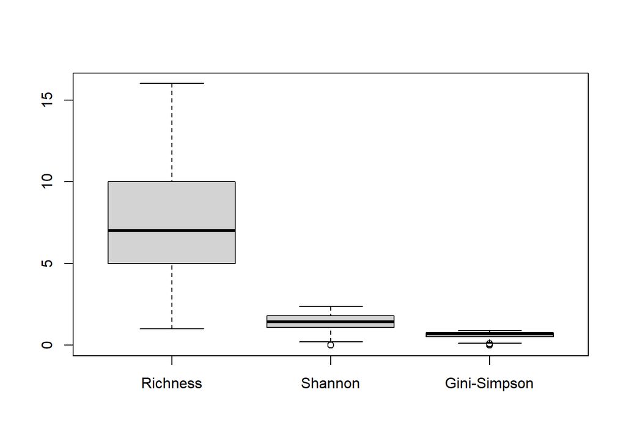

```r
boxplot(cbind(alpha_d0, alpha_sh, alpha_si),
        names = c("Richness", "Shannon", "Gini-Simpson"))
```

If you have heard anyone say that “The Simpson index is more strongly weighted on evenness than the Shannon index”, this is wrong. Since the values are on different scales, it is meaningless to compare them.

### Hill numbers

The older ecology textbooks are mostly outdated because they have not incorporated recent understanding of how the various diversity indices are all related. Luckily, it’s not too difficult to catch up. By simple transformations of the two commonly-used classic diversity indices, the Shannon and the Simpson, we can get them all on the same scale as richness. In fact, they are all sequential along an ‘order’ (commonly denoted as ‘q’) from zero to two.

q = 0 or zeroth order is simply richness.

q = 1 or first order is the exponential of Shannon’s diversity:

```r
(alpha_d1 <- exp(diversity(comm_stem, index = "shannon")))
```

```
##       AD1       AD2       AD3       AD4       AD5       AW1       AW2       AW3
##  3.020825  6.374393  1.777536  1.367162  2.649351  9.311782  5.786959  8.806605
##       AW4       AW5      BBE1      BBE2      BBE3      BBE4      BBE5      BBH1
##  4.832030  2.851973  3.131253  6.774446  4.997757  4.159554  3.057088  6.468744
##      BBH2      BBH3      BBH4      BBH5      BBN1      BBN2      BBN3      BBN4
##  2.119917  5.794539  4.195039  4.101298 10.772454  2.534604  8.723116  3.272560
##      BBN5      BBT1      BBT2      BBT3      BBT4      BBT5       BR1       BR2
##  1.953128  4.666017  4.562733  3.048427  2.584659  1.623413  4.454370  4.128368
##       BR3       CL1       CL2       CL3       CL4       CL5       DO1       DO2
##  1.000000  4.525686  2.226064  4.427100  4.538833  8.191273  6.384001  8.280602
##       DO3       DO4       DO5       GA1       GA2       GA3       GA4       GA5
##  3.935849  4.169059  6.982297  5.797232  4.349034  7.474748  6.865806  5.284657
##       IK1       IK2       IK3       IK4       IK5       JR1       JR2       JR3
##  1.319316  3.691412  1.708103  2.649351  1.822421  1.241609  6.496005  4.430407
##       JR4       JR5       KJ1       KJ2       KJ3       KJ4       KJ5       LD1
##  3.444539  4.814743  5.889116  7.715196  2.299568  6.000000  2.460233  7.332106
##       LD2       LD3       LD4       LD5       PO1       PO2       PO3       PO4
##  4.660698  4.634239  4.413978  4.387465  4.198558  3.543170  3.849372  1.457569
##       PO5       PT1       PT2       PT3       PT4       PT5       SA1       SA2
##  2.079632  4.091097  6.249155  2.363083  6.014548  4.135601  6.388117  7.661279
##       SA3       SA4       SA5       SJ1       SJ2       SJ3       SJ4       SJ5
##  3.521183  5.236115  2.810342  5.536101  8.780028  3.459779  2.000000  4.020341
##       TP1       TP2       TP3       TP4       UT1       UT2       UT3       UT4
##  4.158515  3.469522  3.692948  2.995665  2.148273  8.502749  8.195008  6.624839
##       UT5
##  8.322437
```

q = 2 or second order is another form of the Simpson index, known as the inverse Simpson index.

```r
(alpha_d2 <- diversity(comm_stem, index = "invsimpson"))
```

```
##      AD1      AD2      AD3      AD4      AD5      AW1      AW2      AW3
## 2.176955 4.297619 1.333162 1.142549 2.461538 7.810811 4.631325 7.148515
##      AW4      AW5     BBE1     BBE2     BBE3     BBE4     BBE5     BBH1
## 4.009074 1.957935 1.843200 5.555556 2.689587 2.700000 2.063158 4.694444
##     BBH2     BBH3     BBH4     BBH5     BBN1     BBN2     BBN3     BBN4
## 1.620690 4.432624 2.997783 3.428571 9.057971 1.727862 7.048780 2.033473
##     BBN5     BBT1     BBT2     BBT3     BBT4     BBT5      BR1      BR2
## 1.386509 3.666667 3.061224 1.956182 1.785714 1.275938 4.153846 2.909739
##      BR3      CL1      CL2      CL3      CL4      CL5      DO1      DO2
## 1.000000 3.444444 1.748404 3.529002 3.469880 7.000000 4.681416 6.126050
##      DO3      DO4      DO5      GA1      GA2      GA3      GA4      GA5
## 3.187566 2.593361 6.250000 4.011111 3.382848 4.738028 4.563380 3.284201
##      IK1      IK2      IK3      IK4      IK5      JR1      JR2      JR3
## 1.135255 3.528000 1.412918 2.461538 1.457831 1.097688 5.370937 3.431373
##      JR4      JR5      KJ1      KJ2      KJ3      KJ4      KJ5      LD1
## 2.797688 3.962818 3.853333 7.363636 1.566108 5.142857 2.133333 4.972603
##      LD2      LD3      LD4      LD5      PO1      PO2      PO3      PO4
## 2.845720 2.540741 3.200000 2.700935 2.681021 2.312102 3.103448 1.280000
##      PO5      PT1      PT2      PT3      PT4      PT5      SA1      SA2
## 1.642534 3.654971 4.454545 2.050847 5.236364 3.598639 5.451613 5.903790
##      SA3      SA4      SA5      SJ1      SJ2      SJ3      SJ4      SJ5
## 2.216117 3.660900 1.967658 4.142857 7.510345 2.943958 2.000000 3.319885
##      TP1      TP2      TP3      TP4      UT1      UT2      UT3      UT4
## 3.599572 2.666667 2.780142 2.547368 1.506259 7.246575 5.823529 5.027586
##      UT5
## 6.443787
```

These measures of diversity are called Hill’s equivalent numbers of species. Now, you can say that with increasing order from q = 0 to q = 2, there is increasing weight on evenness or relative abundance of species.

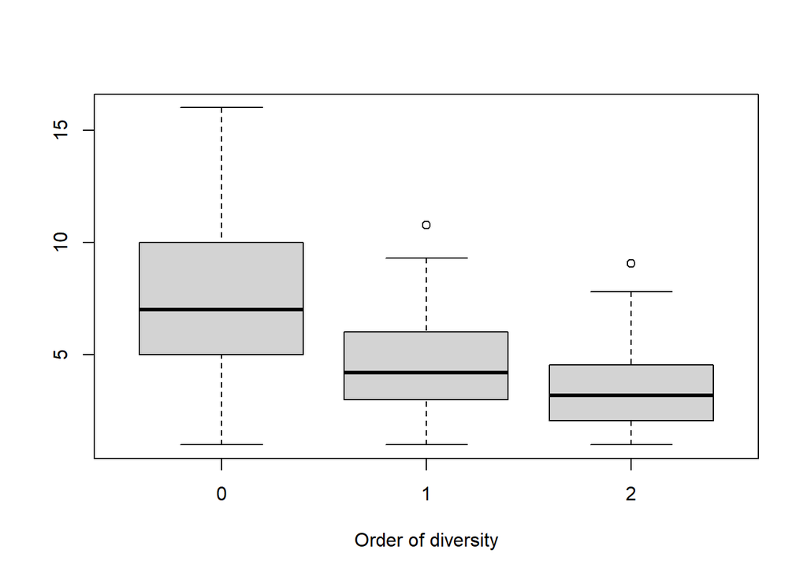

```r
boxplot(cbind(alpha_d0, alpha_d1, alpha_d2),
        names = c(0, 1, 2), xlab = "Order of diversity")
```

It might look like they’re still not on the same ‘scale’, but in fact the reduction in value with increasing order represents the effect of evenness. The equivalent of a ‘number of species’ measure of diversity drops when the community is not perfectly even; vice versa, only when the community is perfectly even will Hill numbers with q>0 be exactly equal to that of q = 0.

### Explore!

The `novelforestSG` package contains the raw data used in the analyses for the scientific paper. You can access the raw data too.

```r
env <- backtransform(download_model()$data)[2:7]
```

```
## To save the model locally, use argument save_to = 'path/filename.rds'
```

```r
head(env)
```

```
##       dist     size nitrogen phosphorous potassium patch
## 1 3293.800 38.15329     2730       17.40      59.1    AD
## 2 3174.000 38.15329     1750        9.32      54.7    AD
## 3 3262.353 38.15329     2590       12.40      82.5    AD
## 4 3315.600 38.15329     2310        6.16      76.6    AD
## 5 3358.000 38.15329     2520        6.51      53.9    AD
## 6 3671.503 21.44964     2660       23.60      71.2    AW
```

Or, you can play around with your own data.

1. Calculate the average alpha diversity of each patch

```r
aggregate(alpha_d0 ~ env$patch, FUN = mean)
```

```
##    env$patch  alpha_d0
## 1         AD  5.600000
## 2         AW  9.600000
## 3        BBE  9.400000
## 4        BBH  7.400000
## 5        BBN  9.200000
## 6        BBT  6.400000
## 7         BR  4.333333
## 8         CL  7.000000
## 9         DO  8.400000
## 10        GA 12.000000
## 11        IK  3.200000
## 12        JR  6.200000
## 13        KJ  6.600000
## 14        LD  9.600000
## 15        PO  5.200000
## 16        PT  6.200000
## 17        SA  8.400000
## 18        SJ  6.400000
## 19        TP  5.500000
## 20        UT  9.800000
```

2. Plots of diversity against environmental/landscape variables

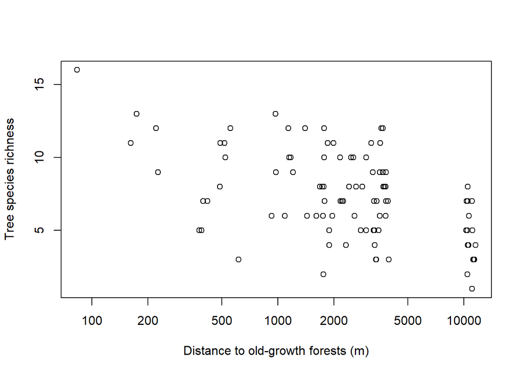

```r
plot(alpha_d0 ~ env$dist, log = "x",
     xlab = "Distance to old-growth forests (m)",
     ylab = "Tree species richness")
```

## Part II: Species accumulation

When you have multiple samples in one area, the total number of species across the samples is (usually) higher than the average number of species per sample. This is because some samples have species that the other samples don’t have.

The second part of this session looks into estimating the *total* number of species as samples accumulate. Some functions for doing this are available in the `vegan` package, but others are available in the `iNEXT` package.

```r
library(iNEXT)
```

Let’s treat all 97 plots as samples of one ‘meta-community’.

```r
comm_stem_meta <- colSums(comm_stem)
```

```r
gamma_comm_stem_meta <- iNEXT(comm_stem_meta, q = 0)
```

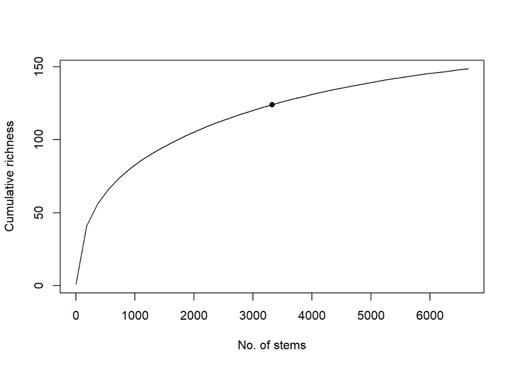

```r
plot(qD ~ m,
     data = gamma_comm_stem_meta$iNextEst$size_based,
     type = "n", lty = 2,
     xlab = "No. of stems",
     ylab = "Cumulative richness")
lines(qD ~ m,
     data = gamma_comm_stem_meta$iNextEst$size_based,
     lty = 1)
lines(qD ~ m,
     data = gamma_comm_stem_meta$iNextEst$size_based,
     subset = Method == "Rarefaction",
     lty = 1)
points(qD ~ m,
       data = gamma_comm_stem_meta$iNextEst$size_based,
       subset = Method == "Observed",
       pch = 16)
```

Since many are familiar with ggplot, let’s use ggplot to plot the species accumulation curve:

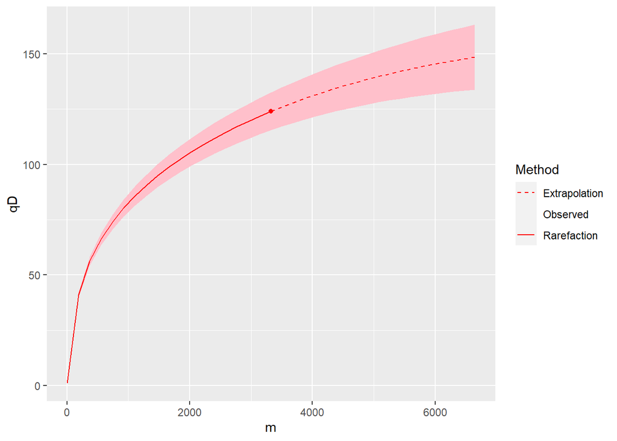

```r
library(ggplot2)

ggplot(data = gamma_comm_stem_meta$iNextEst$size_based,
       mapping = aes(x = m)) +
  geom_ribbon(mapping = aes(ymin = qD.LCL, ymax = qD.UCL), fill = "pink") +
  geom_line(mapping = aes(y = qD, linetype = Method), color = "red") +
  scale_linetype_manual(values = c("dashed", "blank", "solid")) +
  geom_point(data = subset(gamma_comm_stem_meta$iNextEst$size_based,
                           Method == "Observed"),
             mapping = aes(x = m, y = qD), color = "red")
```

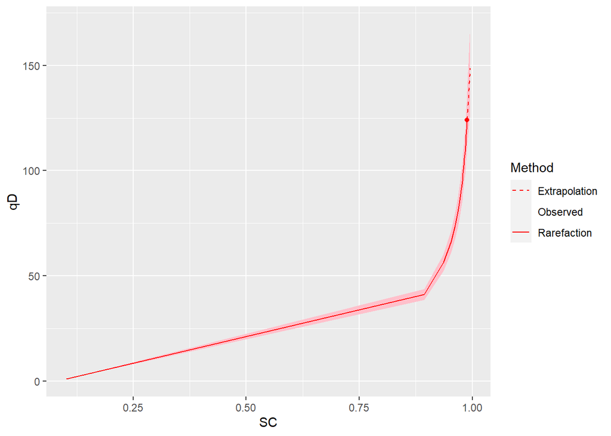

```r
ggplot(data = gamma_comm_stem_meta$iNextEst$coverage_based,
       mapping = aes(x = SC)) +
  geom_ribbon(mapping = aes(ymin = qD.LCL, ymax = qD.UCL), fill = "pink") +
  geom_line(mapping = aes(y = qD, linetype = Method), color = "red") +
  scale_linetype_manual(values = c("dashed", "blank", "solid")) +
  geom_point(data = subset(gamma_comm_stem_meta$iNextEst$size_based,
                           Method == "Observed"),
             mapping = aes(x = SC, y = qD), color = "red")
```